# Weather VPdef (Row 1-100)

Fatima Azzahra - G1401231036

2025-08-31

```r
library("lubridate")
library("readr")
library("readxl")
library("dplyr")
library("forecast")
```

```r
library("graphics")
library("TTR")
library("TSA")
library("ggplot2")
```

# Import Dataset and Data Preparation

**Description** Dataset ini merupakan pencatatan berbagai macam komponen terkait cuaca dengan periode pencatatan per 10 menit dari tanggal 1 Januari 2020 sampai 31 Desember 2020. Analisis akan difokuskan pada peubah VPdef (Vapor Pressure Deficit).

Terkait cakupan analisis untuk tugas ini, akan dianalisis 100 baris pertama untuk peubah VPdef dengan cakupan periodenya yaitu 1 Januari 2020 pada menit ke-10 sampai 16:40.

```r
weather <- read_csv("D:\\TAHUN 3\\G1_MPDW\\cleaned_weather.csv")
View(weather)
str(weather)
```

```
## spc_tbl_ [52,696 × 21] (S3: spec_tbl_df/tbl_df/tbl/data.frame)
##  $ date    : chr [1:52696] "1/1/2020 0:10" "1/1/2020 0:20" "1/1/2020 0:30" "1/1/2020 0:40" ...
##  $ p       : num [1:52696] 1009 1009 1009 1009 1009 ...
##  $ T       : num [1:52696] 0.71 0.75 0.73 0.37 0.33 0.34 0.19 0.03 0.11 0.22 ...
##  $ Tpot    : num [1:52696] 273 273 273 273 273 ...
##  $ Tdew    : num [1:52696] -1.33 -1.44 -1.48 -1.64 -1.5 -1.54 -1.65 -1.7 -1.61 -1.62 ...
##  $ rh      : num [1:52696] 86.1 85.2 85.1 86.3 87.4 87.1 87.4 88.1 88.1 87.4 ...
##  $ VPmax   : num [1:52696] 6.43 6.45 6.44 6.27 6.26 6.26 6.19 6.12 6.16 6.2 ...
##  $ VPact   : num [1:52696] 5.54 5.49 5.48 5.41 5.47 5.45 5.41 5.39 5.43 5.42 ...
##  $ VPdef   : num [1:52696] 0.89 0.95 0.96 0.86 0.79 0.81 0.78 0.73 0.73 0.78 ...
##  $ sh      : num [1:52696] 3.42 3.39 3.39 3.35 3.38 3.37 3.34 3.33 3.35 3.35 ...
##  $ H2OC    : num [1:52696] 5.49 5.45 5.43 5.37 5.42 5.41 5.37 5.35 5.38 5.38 ...
##  $ rho     : num [1:52696] 1281 1280 1280 1282 1282 ...
##  $ wv      : num [1:52696] 1.02 0.43 0.61 1.11 0.49 0.63 0.88 1.05 0.9 0.62 ...
##  $ max. wv : num [1:52696] 1.6 0.84 1.48 1.48 1.4 1.32 1.28 1.64 1.72 1.04 ...
##  $ wd      : num [1:52696] 224 207 197 206 210 ...
##  $ rain    : num [1:52696] 0 0 0 0 0 0 0 0 0 0 ...
##  $ raining : num [1:52696] 0 0 0 0 0 0 0 0 0 0 ...
##  $ SWDR    : num [1:52696] 0 0 0 0 0 0 0 0 0 0 ...
##  $ PAR     : num [1:52696] 0 0 0 0 0 0 0 0 0 0 ...
##  $ max. PAR: num [1:52696] 0 0 0 0 0 0 0 0 0 0 ...
##  $ Tlog    : num [1:52696] 11.4 11.5 11.6 11.7 11.8 ...
##  - attr(*, "spec")=
##   .. cols(
##   ..   date = col_character(),
##   ..   p = col_double(),
##   ..   T = col_double(),
##   ..   Tpot = col_double(),
##   ..   Tdew = col_double(),
##   ..   rh = col_double(),
##   ..   VPmax = col_double(),
##   ..   VPact = col_double(),
##   ..   VPdef = col_double(),
##   ..   sh = col_double(),
##   ..   H2OC = col_double(),
##   ..   rho = col_double(),
##   ..   wv = col_double(),
##   ..   `max. wv` = col_double(),
##   ..   wd = col_double(),
##   ..   rain = col_double(),
##   ..   raining = col_double(),
##   ..   SWDR = col_double(),
##   ..   PAR = col_double(),
##   ..   `max. PAR` = col_double(),
##   ..   Tlog = col_double()
##   .. )
##  - attr(*, "problems")=<externalptr>
```

```r
# Change date format from chr to datetime
weather <- weather %>%
  mutate(datetime = mdy_hm(date))
# new dataframe with datetime and VPdef as respond variable
weather1 <- weather %>%
  select(datetime, VPdef)
View(weather1)
str(weather1)
```

```
## tibble [52,696 × 2] (S3: tbl_df/tbl/data.frame)
##  $ datetime: POSIXct[1:52696], format: "2020-01-01 00:10:00" "2020-01-01 00:20:00" ...
##  $ VPdef   : num [1:52696] 0.89 0.95 0.96 0.86 0.79 0.81 0.78 0.73 0.73 0.78 ...
```

```r
# Check if there's missing value from time frequency per day
weather1 %>%
  group_by(date_only = as.Date(datetime)) %>%
  summarise(n_obs = n(), .groups = "drop") %>%
  filter(n_obs != 144)
```

```
## # A tibble: 4 × 2
##   date_only  n_obs
##   <date>     <int>
## 1 2020-01-01   143
## 2 2020-05-12   145
## 3 2020-05-29   135
## 4 2021-01-01     1
```

**Note: Missing Value and Duplicate**

# Exploring My Data Partition: Row 1-100

```r
# Create the data subset
w1 <- weather1[1:100,]
head(w1, 20)
```

```
## # A tibble: 20 × 2
##    datetime            VPdef
##    <dttm>              <dbl>
##  1 2020-01-01 00:10:00  0.89
##  2 2020-01-01 00:20:00  0.95
##  3 2020-01-01 00:30:00  0.96
##  4 2020-01-01 00:40:00  0.86
##  5 2020-01-01 00:50:00  0.79
##  6 2020-01-01 01:00:00  0.81
##  7 2020-01-01 01:10:00  0.78
##  8 2020-01-01 01:20:00  0.73
##  9 2020-01-01 01:30:00  0.73
## 10 2020-01-01 01:40:00  0.78
## 11 2020-01-01 01:50:00  0.76
## 12 2020-01-01 02:00:00  0.66
## 13 2020-01-01 02:10:00  0.69
## 14 2020-01-01 02:20:00  0.72
## 15 2020-01-01 02:30:00  0.67
## 16 2020-01-01 02:40:00  0.72
## 17 2020-01-01 02:50:00  0.69
## 18 2020-01-01 03:00:00  0.7
## 19 2020-01-01 03:10:00  0.68
## 20 2020-01-01 03:20:00  0.62
```

```r
View(w1)
```

```r
# Change the data format to time series using 'ts' function
w1.ts <- ts(w1$VPdef)
summary(w1.ts)
```

```
##    Min. 1st Qu.  Median    Mean 3rd Qu.    Max.
##  0.2500  0.3475  0.7250  0.9988  1.5225  2.7000
```

```r
w1.ts
```

```
## Time Series:
## Start = 1
## End = 100
## Frequency = 1
##   [1] 0.89 0.95 0.96 0.86 0.79 0.81 0.78 0.73 0.73 0.78 0.76 0.66 0.69 0.72 0.67
##  [16] 0.72 0.69 0.70 0.68 0.62 0.54 0.53 0.52 0.52 0.48 0.47 0.52 0.42 0.41 0.36
##  [31] 0.40 0.34 0.32 0.32 0.30 0.30 0.29 0.27 0.26 0.25 0.25 0.26 0.29 0.31 0.30
##  [46] 0.29 0.28 0.27 0.27 0.27 0.26 0.30 0.31 0.29 0.30 0.32 0.35 0.38 0.38 0.47
##  [61] 0.69 0.77 0.78 0.75 0.80 0.75 0.82 0.84 0.89 0.90 0.97 1.15 1.27 1.33 1.50
##  [76] 1.59 1.82 1.93 1.95 2.01 2.34 2.36 2.45 2.33 2.18 2.27 2.40 2.39 2.58 2.70
##  [91] 2.52 2.43 2.59 2.64 2.62 2.36 2.12 2.01 1.98 1.94
```

**Note: Time Series Data Frequency**

Pada tahap eksplorasi awal ini digunakan frequency = 1 karena baru mengamati observasi dalam skala yang kecil.

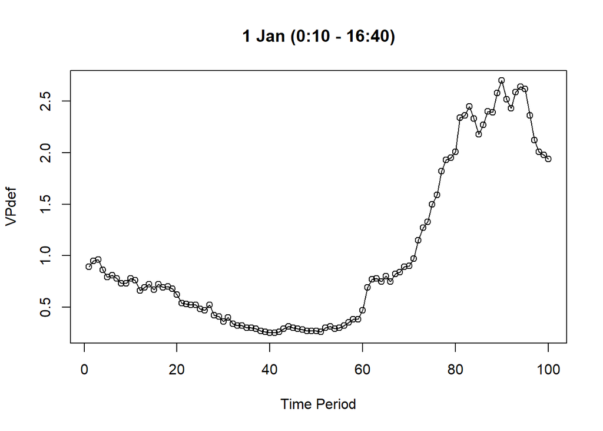

```r
ts.plot(w1.ts, xlab="Time Period", ylab="VPdef",
        main = "1 Jan (0:10 - 16:40)")
points(w1.ts)
```

Berdasarkan plot, data deret waktunya **tidak stasioner**.

### Splitting Data into Training and Testing

Pembagian data latih dan data uji dilakukan dengan perbandingan **80:20** untuk data latih dan data uji.

```r
#split training data and testing data
training <- w1[1:80,]
testing <- w1[81:100,]
train.ts <- ts(training$VPdef)
test.ts <- ts(testing$VPdef)
```

### Plotting Time Series Data

Eksplorasi data dilakukan pada keseluruhan data, data latih serta data uji menggunakan plot data deret waktu.

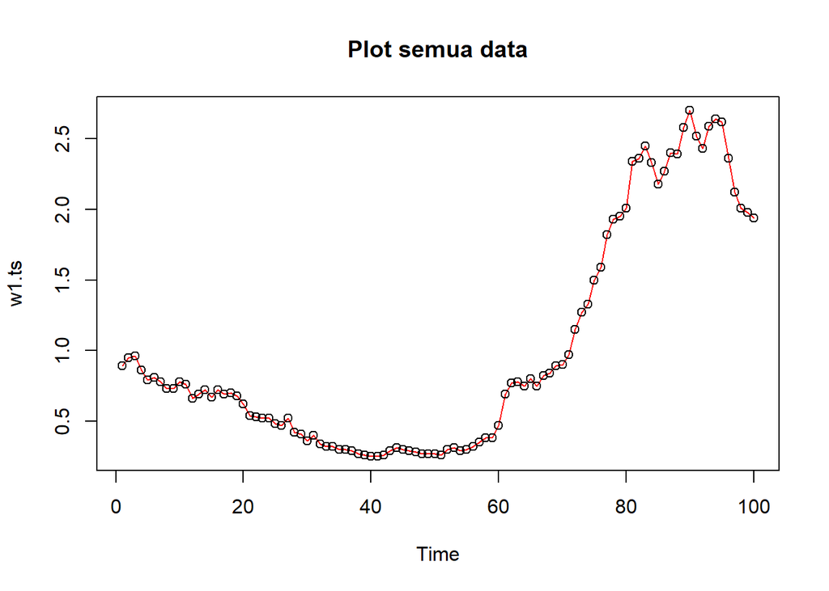

```r
# explore entire data
plot(w1.ts, col="red",main="Plot semua data")
points(w1.ts)
```

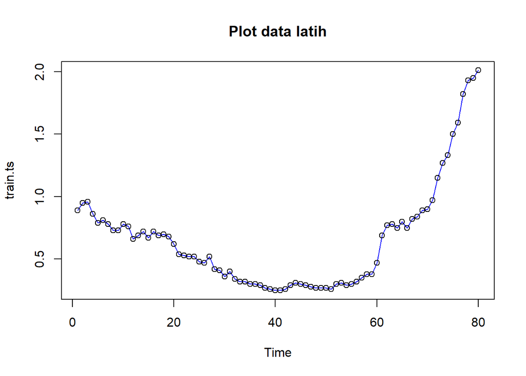

```r
# explore training data
plot(train.ts, col="blue",main="Plot data latih")
points(train.ts)
```

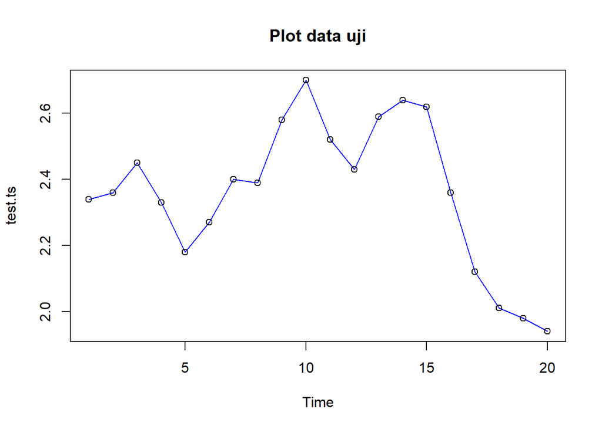

```r
# explore testing data
plot(test.ts, col="blue",main="Plot data uji")
points(test.ts)
```

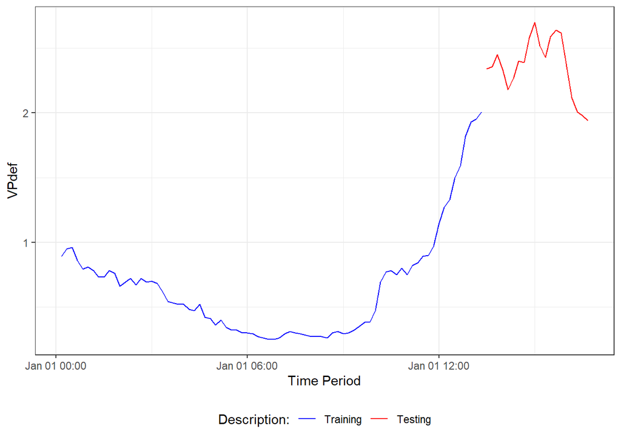

```r
# explore with ggplot2
library(ggplot2)
ggplot() +
  geom_line(data = training, aes(x = datetime, y = VPdef, col = "Training")) +
  geom_line(data = testing, aes(x = datetime, y = VPdef, col = "Testing")) +
  labs(x = "Time Period", y = "VPdef", color = "Legend") +
  scale_colour_manual(name="Description:", breaks = c("Training", "Testing"),
                      values = c("blue", "red")) +
  theme_bw() + theme(legend.position = "bottom",
                     plot.caption = element_text(hjust=0.5, size=12))
```

### Single Exponential Smoothing

- **Ide dasar**: Data yang terdahulu tidak terlalu berpengaruh pada data saat ini. Memberikan pembobotan eksponensial menurun, nilai data yang lebih baru, bobotnya lebih besar dibanding data terdahulu.
- **Tipe**: pola stasioner atau konstan.
- **Prinsip** **dasar**:

  Nilai pemulusan pada periode ke-t didapat dari persamaan:

  $$\tilde{y}_T=\lambda y_t+(1-\lambda)\tilde{y}_{T-1}$$

  Nilai parameter $\lambda$ adalah nilai antara 0 dan 1.

  Nilai pemulusan periode ke-t bertindak sebagai nilai ramalan pada periode ke-$(T+\tau)$.

  $$\tilde{y}_{T+\tau}(T)=\tilde{y}_T$$

SES menggunakan fungsi **HoltWinters()** dengan nilai **alpha = 0.7** dan nilai **alpha optimal** saat alpha dibuat NULL.

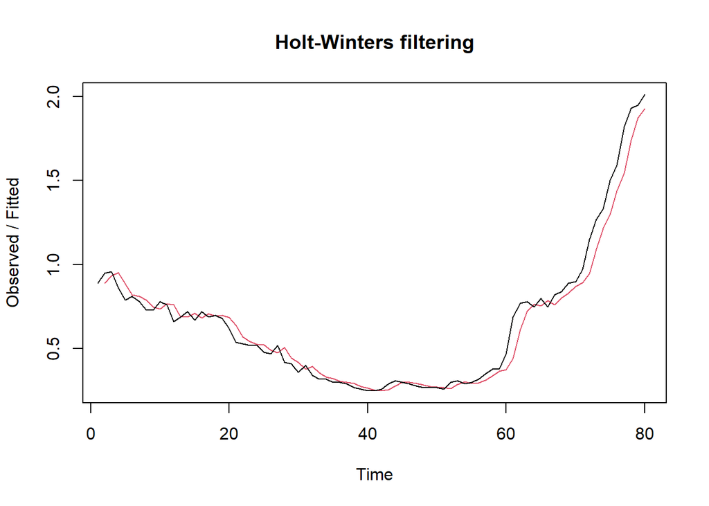

```r
# SES with HoltWinters function
ses<- HoltWinters(train.ts, gamma = FALSE, beta = FALSE, alpha = 0.7)
plot(ses)
```

```r
# Forecast
ramal<- forecast(ses, h=20)
ramal
```

```
##     Point Forecast    Lo 80    Hi 80    Lo 95    Hi 95
##  81       1.984999 1.887020 2.082979 1.835153 2.134846
##  82       1.984999 1.865400 2.104598 1.802088 2.167910
##  83       1.984999 1.847130 2.122869 1.774147 2.195852
##  84       1.984999 1.831013 2.138986 1.749497 2.220502
##  85       1.984999 1.816429 2.153569 1.727194 2.242805
##  86       1.984999 1.803011 2.166988 1.706672 2.263327
##  87       1.984999 1.790516 2.179483 1.687562 2.282436
##  88       1.984999 1.778777 2.191222 1.669609 2.300390
##  89       1.984999 1.767671 2.202328 1.652624 2.317375
##  90       1.984999 1.757105 2.212894 1.636465 2.333534
##  91       1.984999 1.747008 2.222990 1.621023 2.348975
##  92       1.984999 1.737323 2.232676 1.606211 2.363788
##  93       1.984999 1.728002 2.241997 1.591956 2.378043
##  94       1.984999 1.719007 2.250991 1.578200 2.391799
##  95       1.984999 1.710307 2.259691 1.564894 2.405105
##  96       1.984999 1.701875 2.268124 1.551997 2.418001
##  97       1.984999 1.693686 2.276313 1.539474 2.430525
##  98       1.984999 1.685721 2.284278 1.527292 2.442706
##  99       1.984999 1.677963 2.292036 1.515427 2.454572
## 100       1.984999 1.670395 2.299603 1.503854 2.466144
```

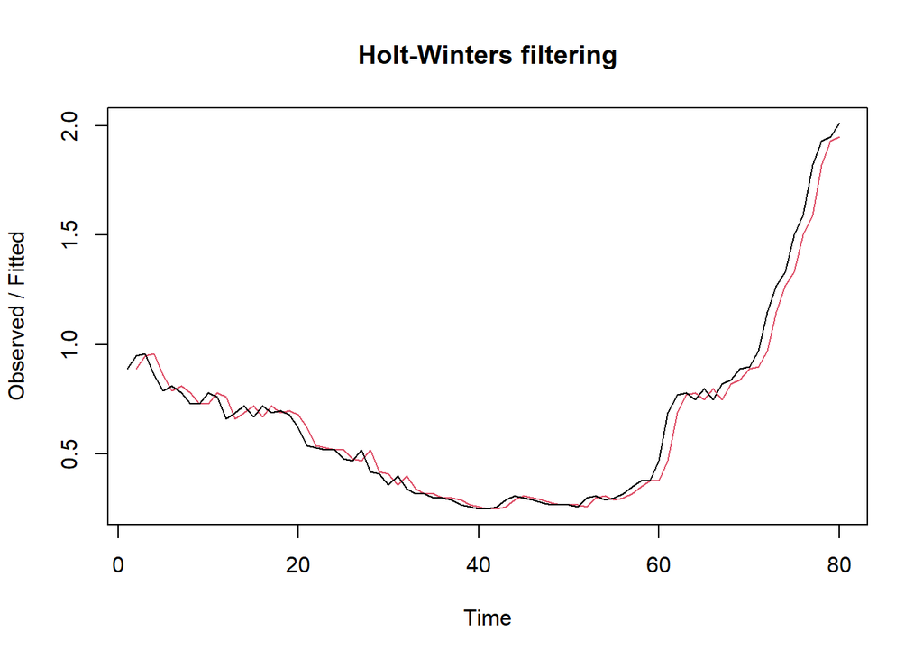

```r
# SES with HoltWinters function
ses.opt<- HoltWinters(train.ts, gamma = FALSE, beta = FALSE, alpha = NULL)
plot(ses.opt)
```

```r
ses.opt
```

```
## Holt-Winters exponential smoothing without trend and without seasonal component.
##
## Call:
## HoltWinters(x = train.ts, alpha = NULL, beta = FALSE, gamma = FALSE)
##
## Smoothing parameters:
##  alpha: 0.9999577
##  beta : FALSE
##  gamma: FALSE
##
## Coefficients:
##       [,1]
## a 2.009997
```

```r
# Forecast
ramal.opt<- forecast(ses.opt, h=20)
ramal.opt
```

```
##     Point Forecast    Lo 80    Hi 80    Lo 95    Hi 95
##  81       2.009997 1.929763 2.090232 1.887290 2.132705
##  82       2.009997 1.896531 2.123463 1.836466 2.183529
##  83       2.009997 1.871032 2.148963 1.797467 2.222528
##  84       2.009997 1.849534 2.170461 1.764590 2.255405
##  85       2.009997 1.830594 2.189401 1.735624 2.284371
##  86       2.009997 1.813471 2.206524 1.709437 2.310558
##  87       2.009997 1.797725 2.222270 1.685355 2.334640
##  88       2.009997 1.783069 2.236926 1.662940 2.357055
##  89       2.009997 1.769304 2.250691 1.641888 2.378107
##  90       2.009997 1.756284 2.263711 1.621976 2.398019
##  91       2.009997 1.743901 2.276094 1.603038 2.416957
##  92       2.009997 1.732068 2.287926 1.584942 2.435053
##  93       2.009997 1.720720 2.299275 1.567586 2.452409
##  94       2.009997 1.709800 2.310195 1.550885 2.469110
##  95       2.009997 1.699264 2.320731 1.534771 2.485224
##  96       2.009997 1.689073 2.330922 1.519186 2.500809
##  97       2.009997 1.679196 2.340799 1.504081 2.515914
##  98       2.009997 1.669606 2.350389 1.489413 2.530582
##  99       2.009997 1.660278 2.359717 1.475148 2.544847
## 100       2.009997 1.651193 2.368802 1.461254 2.558741
```

Setelah dilakukan peramalan, akan dilakukan perhitungan keakuratan hasil peramalan. Perhitungan akurasi ini dilakukan baik pada data latih dan data uji.

#### Akurasi Data Latih SES

```r
# Manual procedure
fitted<-ramal$fitted
sisaan<-ramal$residuals
head(sisaan)
```

```
## Time Series:
## Start = 1
## End = 6
## Frequency = 1
## [1]        NA  0.060000  0.028000 -0.091600 -0.097480 -0.009244
```

```r
resid<-training$VPdef-ramal$fitted
head(resid)
```

```
## Time Series:
## Start = 1
## End = 6
## Frequency = 1
## [1]        NA  0.060000  0.028000 -0.091600 -0.097480 -0.009244
```

```r
SSE = sum(sisaan[2:length(train.ts)]^2)
MSE = SSE/length(train.ts)
MAPE = sum(abs(sisaan[2:length(train.ts)]/train.ts[2:length(train.ts)])*
               100)/length(train.ts)

akurasi <- matrix(c(SSE,MSE,MAPE))
row.names(akurasi)<- c("SSE", "MSE", "MAPE")
colnames(akurasi) <- c("Akurasi lamda = 0.7")
akurasi
```

```
##      Akurasi lamda = 0.7
## SSE          0.486897968
## MSE          0.006086225
## MAPE         7.484437799
```

```r
fitted.opt<-ramal.opt$fitted
sisaan.opt<-ramal.opt$residuals
head(sisaan.opt)
```

```
## Time Series:
## Start = 1
## End = 6
## Frequency = 1
## [1]          NA  0.06000000  0.01000254 -0.09999958 -0.07000423  0.01999704
```

```r
resid.opt<-training$VPdef-ramal.opt$fitted
head(resid.opt)
```

```
## Time Series:
## Start = 1
## End = 6
## Frequency = 1
## [1]          NA  0.06000000  0.01000254 -0.09999958 -0.07000423  0.01999704
```

```r
SSE.opt=sum(sisaan.opt[2:length(train.ts)]^2)
MSE.opt = SSE.opt/length(train.ts)
MAPE.opt = sum(abs(sisaan.opt[2:length(train.ts)]/train.ts[2:length(train.ts)])*
               100)/length(train.ts)

akurasi.opt <- matrix(c(SSE.opt,MSE.opt,MAPE.opt))
row.names(akurasi.opt)<- c("SSE", "MSE", "MAPE")
colnames(akurasi.opt) <- c("Akurasi lamda = 0.99")
akurasi.opt
```

```
##      Akurasi lamda = 0.99
## SSE           0.321612873
## MSE           0.004020161
## MAPE          6.326536579
```

#### Akurasi Data Uji SES

```r
selisih<-ramal$mean-testing$VPdef
SSEtesting<-sum(selisih^2)
MSEtesting<-SSEtesting/length(testing)

selisih.opt<-ramal.opt$mean-testing$VPdef
SSEtesting.opt<-sum(selisih.opt^2)
MSEtesting.opt<-SSEtesting.opt/length(testing)

akurasitesting1 <- matrix(c(SSEtesting,SSEtesting.opt))
row.names(akurasitesting1)<- c("SSE", "SSEopt")
akurasitesting1
```

```
##            [,1]
## SSE    3.766709
## SSEopt 3.403736
```

```r
akurasitesting2 <- matrix(c(MSEtesting,MSEtesting.opt))
row.names(akurasitesting2)<- c("MSE", "MSEopt")
akurasitesting2
```

```
##            [,1]
## MSE    1.883355
## MSEopt 1.701868
```

#### Kesimpulan SES

```r
# Use accuracy() function from package 'forecast'
accuracy(ramal,testing$VPdef)
```

```
##                      ME       RMSE        MAE        MPE      MAPE     MASE
## Training set 0.01980107 0.07850647 0.05268728  0.7977442  7.579178 1.224205
## Test set     0.37550063 0.43397635 0.38050051 15.1503610 15.407566 8.841041
##                   ACF1
## Training set 0.6995937
## Test set            NA
```

```r
accuracy(ramal.opt,testing$VPdef)
```

```
##                      ME       RMSE        MAE       MPE      MAPE     MASE
## Training set 0.01417778 0.06380477 0.04303894  0.650792  6.406619 1.000022
## Test set     0.35050254 0.41253700 0.36050203 14.081807 14.594121 8.376371
##                   ACF1
## Training set 0.4508479
## Test set            NA
```

Berdasarkan nilai SSE, MSE,dan MAPE, kedua parameter memiliki perbedaan nilai yang tidak terlalu jauh. Tetapi, parameter $\lambda = 0.7$ sudah cukup akurat dalam merepresentasikan data.

### Double Exponensial Smoothing

- **Ide dasar**: Mirip SES tetapi pemulusannya dua kali yaitu untuk tahapan *level* dan *tren*. Hasil peramalannya tidak konstan untuk periode berikutnya.
- **Tipe**: pola tren.

DES menggunakan fungsi **HoltWinters()** dengan nilai *beta = 0.7*, *alpha = 0.8* dan versi NULL.

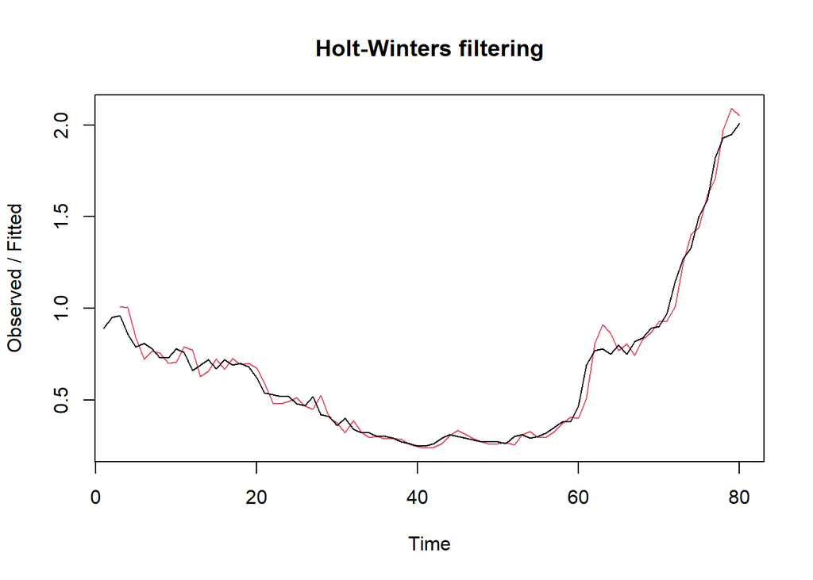

```r
# Lamda=0.7 & gamma=0.5
des<- HoltWinters(train.ts, gamma = FALSE, beta = 0.7, alpha = 0.8)
plot(des)
```

```r
# Forecast
ramaldes<- forecast(des, h=20)
ramaldes
```

```
##     Point Forecast     Lo 80    Hi 80      Lo 95    Hi 95
##  81       2.068164 1.9934319 2.142896  1.9538711 2.182457
##  82       2.118147 1.9919938 2.244301  1.9252122 2.311082
##  83       2.168131 1.9770735 2.359188  1.8759339 2.460327
##  84       2.218114 1.9519333 2.484295  1.8110257 2.625202
##  85       2.268097 1.9181466 2.618048  1.7328939 2.803301
##  86       2.318080 1.8766673 2.759494  1.6429972 2.993164
##  87       2.368064 1.8281606 2.907967  1.5423531 3.193775
##  88       2.418047 1.7731301 3.062964  1.4317317 3.404362
##  89       2.468030 1.7119777 3.224083  1.3117476 3.624313
##  90       2.518014 1.6450350 3.390992  1.1829081 3.853119
##  91       2.567997 1.5725831 3.563411  1.0456428 4.090351
##  92       2.617980 1.4948642 3.741096  0.9003224 4.335638
##  93       2.667964 1.4120903 3.923837  0.7472712 4.588656
##  94       2.717947 1.3244495 4.111444  0.5867766 4.849117
##  95       2.767930 1.2321096 4.303751  0.4190954 5.116765
##  96       2.817913 1.1352222 4.500605  0.2444593 5.391367
##  97       2.867897 1.0339248 4.701869  0.0630788 5.672715
##  98       2.917880 0.9283431 4.907417 -0.1248540 5.960614
##  99       2.967863 0.8185925 5.117134 -0.3191627 6.254889
## 100       3.017847 0.7047795 5.330914 -0.5196843 6.555377
```

```r
# Lamda=0.7 & gamma-optimal
des.opt<- HoltWinters(train.ts, gamma = FALSE)
des.opt
```

```
## Holt-Winters exponential smoothing with trend and without seasonal component.
##
## Call:
## HoltWinters(x = train.ts, gamma = FALSE)
##
## Smoothing parameters:
##  alpha: 1
##  beta : 0.2384815
##  gamma: FALSE
##
## Coefficients:
##         [,1]
## a 2.01000000
## b 0.09016799
```

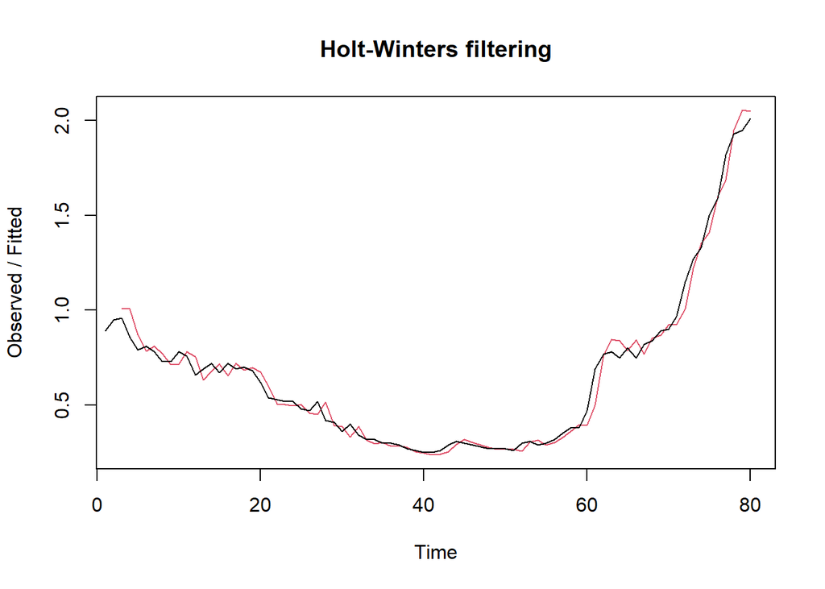

```r
plot(des.opt)
```

```r
# Forecast
ramaldes.opt<- forecast(des.opt, h=20)
ramaldes.opt
```

```
##     Point Forecast    Lo 80    Hi 80    Lo 95    Hi 95
##  81       2.100168 2.030011 2.170325 1.992872 2.207464
##  82       2.190336 2.078659 2.302013 2.019541 2.361131
##  83       2.280504 2.128160 2.432848 2.047514 2.513494
##  84       2.370672 2.176525 2.564819 2.073750 2.667594
##  85       2.460840 2.223175 2.698505 2.097363 2.824317
##  86       2.551008 2.267912 2.834103 2.118051 2.983965
##  87       2.641176 2.310679 2.971673 2.135724 3.146628
##  88       2.731344 2.351475 3.111213 2.150384 3.312304
##  89       2.821512 2.390328 3.252696 2.162073 3.480951
##  90       2.911680 2.427278 3.396081 2.170852 3.652508
##  91       3.001848 2.462370 3.541326 2.176787 3.826908
##  92       3.092016 2.495648 3.688384 2.179950 4.004082
##  93       3.182184 2.527158 3.837209 2.180409 4.183959
##  94       3.272352 2.556944 3.987760 2.178230 4.366474
##  95       3.362520 2.585047 4.139993 2.173478 4.551562
##  96       3.452688 2.611507 4.293869 2.166212 4.739164
##  97       3.542856 2.636361 4.449351 2.156492 4.929220
##  98       3.633024 2.659646 4.606402 2.144370 5.121678
##  99       3.723192 2.681394 4.764990 2.129899 5.316485
## 100       3.813360 2.701638 4.925082 2.113128 5.513592
```

Selanjutnya akan dilakukan perhitungan akurasi pada data latih maupun data uji dengan ukuran akurasi SSE, MSE dan MAPE.

#### Akurasi Data Latih DES

```r
ssedes.train<-des$SSE
msedes.train<-ssedes.train/length(train.ts)
sisaandes<-ramaldes$residuals
head(sisaandes)
```

```
## Time Series:
## Start = 1
## End = 6
## Frequency = 1
## [1]         NA         NA -0.0500000 -0.1420000 -0.0508800  0.0858368
```

```r
mapedes.train <- sum(abs(sisaandes[3:length(train.ts)]/train.ts[3:length(train.ts)])
                      *100)/length(train.ts)

akurasides <- matrix(c(ssedes.train,msedes.train,mapedes.train))
row.names(akurasides)<- c("SSE", "MSE", "MAPE")
colnames(akurasides) <- c("Akurasi lamda=0.8 dan gamma=0.7")
akurasides
```

```
##      Akurasi lamda=0.8 dan gamma=0.7
## SSE                       0.26184238
## MSE                       0.00327303
## MAPE                      6.60115010
```

```r
ssedes.train.opt<-des.opt$SSE
msedes.train.opt<-ssedes.train.opt/length(train.ts)
sisaandes.opt<-ramaldes.opt$residuals
head(sisaandes.opt)
```

```
## Time Series:
## Start = 1
## End = 6
## Frequency = 1
## [1]          NA          NA -0.05000000 -0.14807592 -0.08276256  0.02697478
```

```r
mapedes.train.opt <- sum(abs(sisaandes.opt[3:length(train.ts)]/train.ts[3:length(train.ts)])
                      *100)/length(train.ts)

akurasides.opt <- matrix(c(ssedes.train.opt,msedes.train.opt,mapedes.train.opt))
row.names(akurasides.opt)<- c("SSE", "MSE", "MAPE")
colnames(akurasides.opt) <- c("Akurasi lamda=1 dan gamma=0.24")
akurasides.opt
```

```
##      Akurasi lamda=1 dan gamma=0.24
## SSE                     0.230966899
## MSE                     0.002887086
## MAPE                    6.154419921
```

#### Akurasi Data Uji DES

```r
selisihdes<-ramaldes$mean-testing$VPdef
selisihdes
```

```
## Time Series:
## Start = 81
## End = 100
## Frequency = 1
##  [1] -0.27183596 -0.24185267 -0.28186938 -0.11188609  0.08809720  0.04808049
##  [7] -0.03193622  0.02804708 -0.11196963 -0.18198634  0.04799695  0.18798024
## [13]  0.07796353  0.07794682  0.14793011  0.45791340  0.74789669  0.90787999
## [19]  0.98786328  1.07784657
```

```r
SSEtestingdes<-sum(selisihdes^2)
MSEtestingdes<-SSEtestingdes/length(testing$VPdef)
MAPEtestingdes<-sum(abs(selisihdes/testing$VPdef)*100)/length(testing$VPdef)

selisihdes.opt<-ramaldes.opt$mean-testing$VPdef
selisihdes.opt
```

```
## Time Series:
## Start = 81
## End = 100
## Frequency = 1
##  [1] -0.23983201 -0.16966401 -0.16949602  0.04067197  0.28083997  0.28100796
##  [7]  0.24117595  0.34134395  0.24151194  0.21167993  0.48184793  0.66201592
## [13]  0.59218391  0.63235191  0.74251990  1.09268789  1.42285589  1.62302388
## [19]  1.74319187  1.87335987
```

```r
SSEtestingdes.opt<-sum(selisihdes.opt^2)
MSEtestingdes.opt<-SSEtestingdes.opt/length(testing$VPdef)
MAPEtestingdes.opt<-sum(abs(selisihdes.opt/testing$VPdef)*100)/length(testing$VPdef)

akurasitestingdes <-
  matrix(c(SSEtestingdes,MSEtestingdes,MAPEtestingdes,SSEtestingdes.opt,MSEtestingdes.opt,
           MAPEtestingdes.opt),
         nrow=3,ncol=2)
row.names(akurasitestingdes)<- c("SSE", "MSE", "MAPE")
colnames(akurasitestingdes) <- c("des","des opt")
akurasitestingdes
```

```
##             des   des opt
## SSE   4.0844769 14.925559
## MSE   0.2042238  0.746278
## MAPE 14.2232645 29.659322
```

Berdasarkan nilai SSE, MSE,dan MAPE, kombinasi parameter $\lambda = 0.8$ dan $\gamma = 0.7$ memiliki MAPE data uji yang lebih baik dibandingkan parameter optimalnya.

#### Perbandingan SES dan DES

```r
MSEfull <-
  matrix(c(MSEtesting,MSEtesting.opt,MSEtestingdes,MSEtestingdes.opt),nrow=2,ncol=2)
row.names(MSEfull)<- c("ske", "ske opt")
colnames(MSEfull) <- c("ses","des")
MSEfull
```

```
##              ses       des
## ske     1.883355 0.2042238
## ske opt 1.701868 0.7462780
```

# Conclusion

Berdasarkan hasil evaluasi menggunakan metode Double Exponential Smoothing ($\lambda = 0.8$ dan $\gamma = 0.7$), nilai MAPE pada data training (6.6%) dan testing (14.2%) menunjukkan akurasi yang baik, serta nilai MSE yang rendah (0.2), sehingga metode ini dinyatakan cocok untuk data tersebut.